# RIC vs MAC Overall survival (OS) Meta Analysis

Kushal Kumar Dey

Monday, May 18, 2015

[output not shown]

```
##        trials RIC_events RIC_non_events MAC_events MAC_non_events weight
## 1  Marks 2010         36             57        657            771  0.255
## 2  Mohty 2010         37             90        166            283  0.232
## 3    Eom 2013         29             31         60             60  0.127
## 4 Tanaka 2013         84            122        170            199  0.386
```

Meta analysis on the above data is performed on two effects

- Odds Ratio (OR)
- Relative Risk (RR)

## Odds Ratio (OR) analysis

The Odds ratio and its variance are given by

```
##                Y          V
## [1,] -0.29952797 0.04836578
## [2,] -0.35543265 0.05018633
## [3,] -0.06669137 0.10007416
## [4,] -0.21569786 0.03186619
```

```
##
## Fixed-Effects Model (k = 4)
##
##   logLik  deviance       AIC       BIC      AICc
##   1.8866    0.6443   -1.7732   -2.3869    0.2268
##
## Test for Heterogeneity:
## Q(df = 3) = 0.6443, p-val = 0.8862
##
## Model Results:
##
## estimate       se     zval     pval    ci.lb    ci.ub
##  -0.2526   0.1104  -2.2874   0.0222  -0.4691  -0.0362        *
##
## ---
## Signif. codes:  0 '***' 0.001 '**' 0.01 '*' 0.05 '.' 0.1 ' ' 1
```

```
## The confidence interval for the Odds Ratio is given by : CI.lb= 0.625554 Est= 0.7767449 CI.ub= 0.9644774
```

```
##       weights
## [1,] 25.22195
## [2,] 24.30700
## [3,] 12.18975
## [4,] 38.28130
```

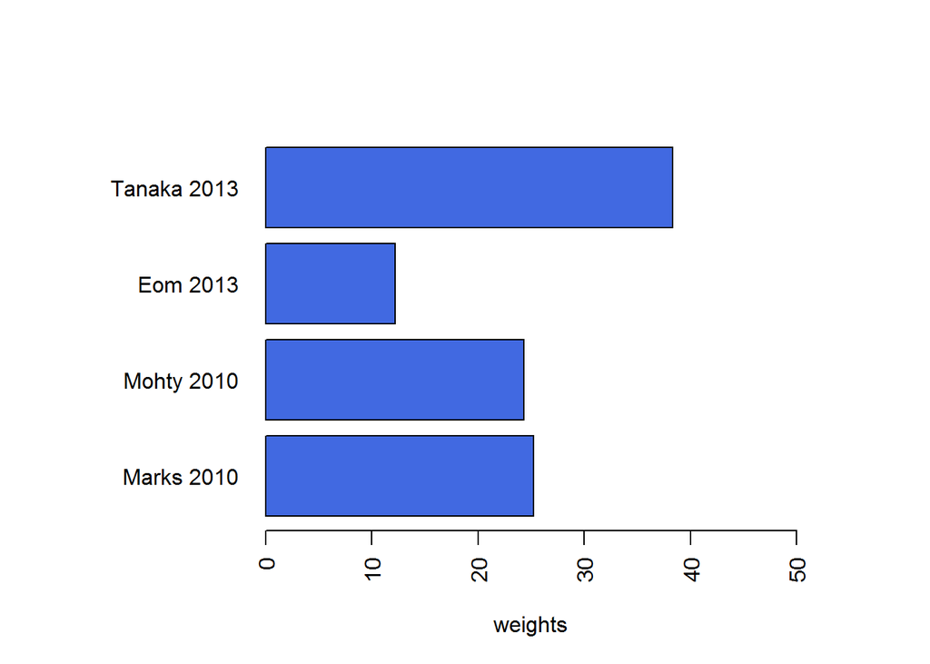

```
##
## Random-Effects Model (k = 4; tau^2 estimator: DL)
##
##   logLik  deviance       AIC       BIC      AICc
##   1.8866    0.6443    0.2268   -1.0006   12.2268
##
## tau^2 (estimated amount of total heterogeneity): 0 (SE = 0.0417)
## tau (square root of estimated tau^2 value):      0
## I^2 (total heterogeneity / total variability):   0.00%
## H^2 (total variability / sampling variability):  1.00
##
## Test for Heterogeneity:
## Q(df = 3) = 0.6443, p-val = 0.8862
##
## Model Results:
##
## estimate       se     zval     pval    ci.lb    ci.ub
##  -0.2526   0.1104  -2.2874   0.0222  -0.4691  -0.0362        *
##
## ---
## Signif. codes:  0 '***' 0.001 '**' 0.01 '*' 0.05 '.' 0.1 ' ' 1
```

```
##       weights
## [1,] 25.22195
## [2,] 24.30700
## [3,] 12.18975
## [4,] 38.28130
```

```
##
## Random-Effects Model (k = 4; tau^2 estimator: REML)
##
##   logLik  deviance       AIC       BIC      AICc
##   1.2955   -2.5909    1.4091   -0.3937   13.4091
##
## tau^2 (estimated amount of total heterogeneity): 0 (SE = 0.0398)
## tau (square root of estimated tau^2 value):      0
## I^2 (total heterogeneity / total variability):   0.00%
## H^2 (total variability / sampling variability):  1.00
##
## Test for Heterogeneity:
## Q(df = 3) = 0.6443, p-val = 0.8862
##
## Model Results:
##
## estimate       se     zval     pval    ci.lb    ci.ub
##  -0.2526   0.1104  -2.2874   0.0222  -0.4691  -0.0362        *
##
## ---
## Signif. codes:  0 '***' 0.001 '**' 0.01 '*' 0.05 '.' 0.1 ' ' 1
```

```
##       weights
## [1,] 25.22195
## [2,] 24.30700
## [3,] 12.18975
## [4,] 38.28130
```

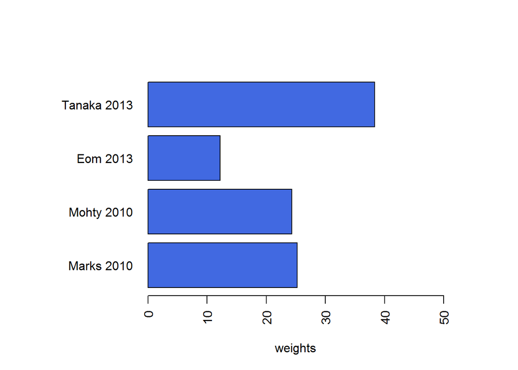

Now we focus on the tests of heterogeneity, the values f $Q$ have been reported above for both the Random effects methods and the Fixed effect method,however $Q$ statistic in this case is not recommended as a measure of heterogeneity bacause the number of trials is small, only 4, and therefore the Q test will have lower power. So, we consider other measures of heterogeneity

The heterogeneity measures for Fixed effect method

```
##
##        estimate  ci.lb   ci.ub
## tau^2        NA 0.0000  0.1415
## tau          NA 0.0000  0.3761
## I^2(%)       NA 0.0000 73.4547
## H^2          NA 1.0000  3.7671
```

The heterogeneity measure for the Random effect DL method

```
##
##        estimate  ci.lb   ci.ub
## tau^2    0.0000 0.0000  0.1415
## tau      0.0000 0.0000  0.3761
## I^2(%)   0.0000 0.0000 73.4547
## H^2      1.0000 1.0000  3.7671
```

The heterogeneity measures for the Random effect REML method

```
##
##        estimate  ci.lb   ci.ub
## tau^2    0.0000 0.0000  0.1415
## tau      0.0000 0.0000  0.3761
## I^2(%)   0.0000 0.0000 73.4547
## H^2      1.0000 1.0000  3.7671
```

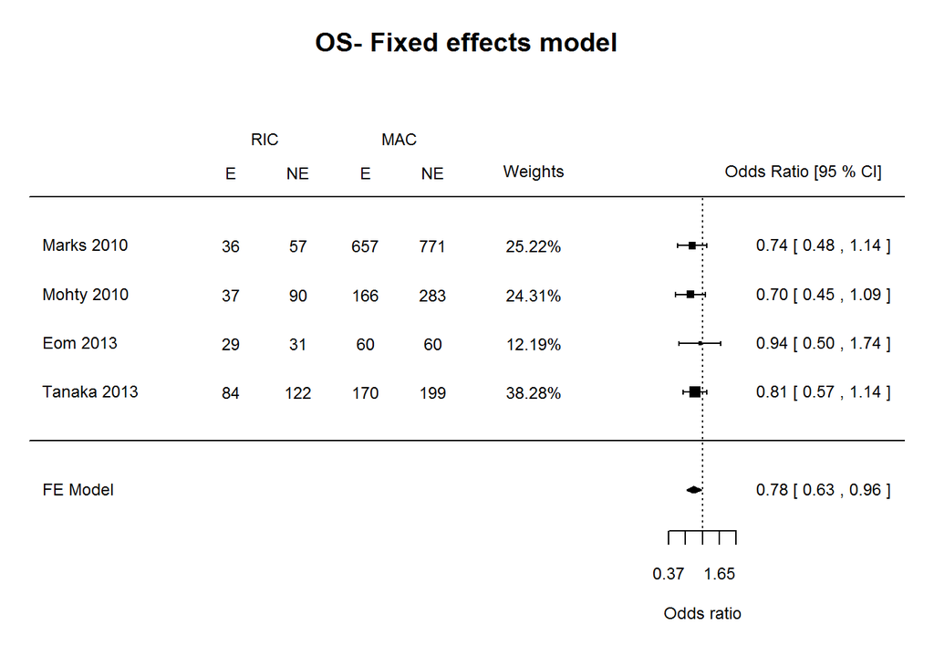

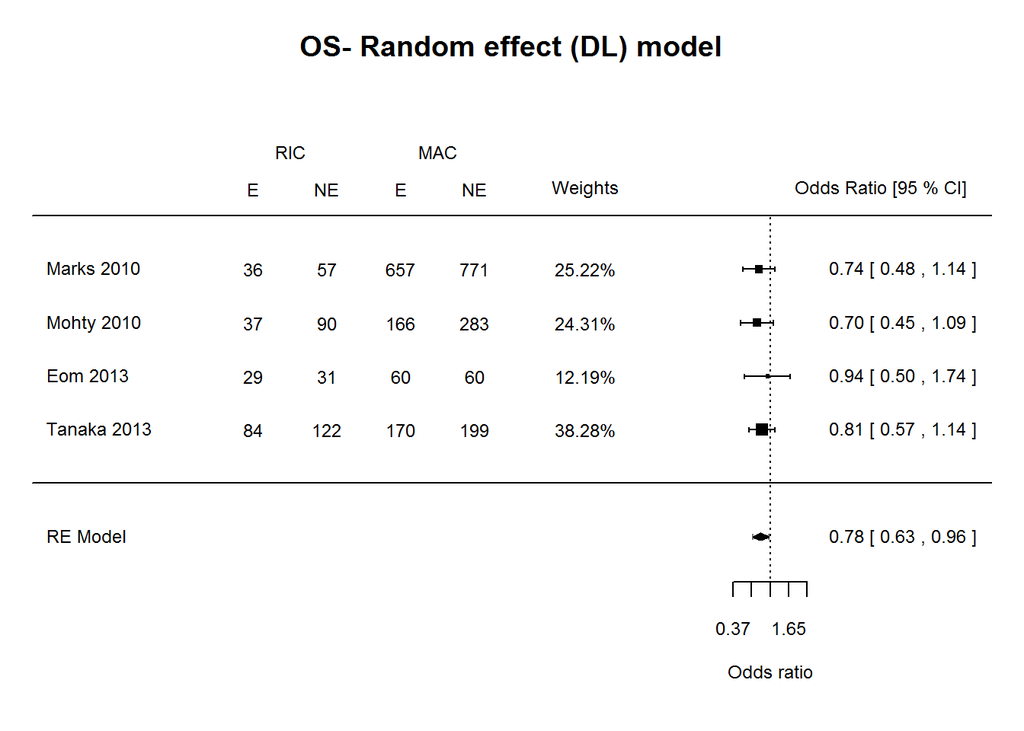

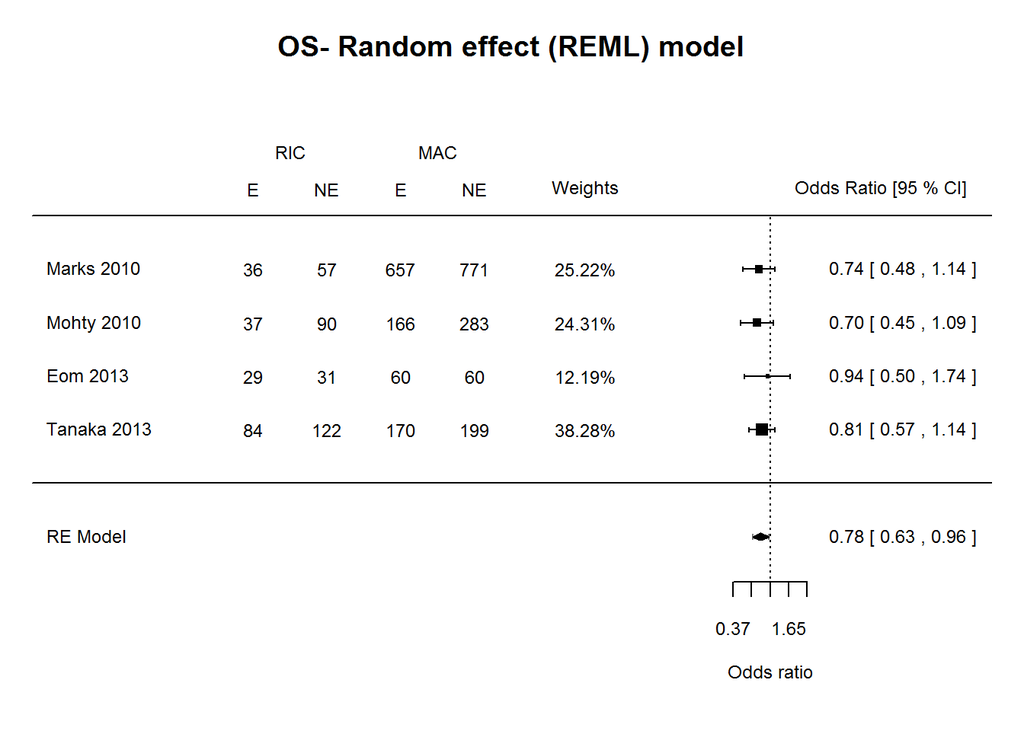

We now consider how sensitive the method is to the removal of one of the trials. For this, we only apply the leave one out sensitivity analysis on the REML random effects method.

```
##   estimate     se    zval   pval   ci.lb   ci.ub      Q     Qp   tau2
## 1  -0.2368 0.1277 -1.8542 0.0637 -0.4872  0.0135 0.5836 0.7469 0.0000
## 2  -0.2196 0.1269 -1.7301 0.0836 -0.4685  0.0292 0.3662 0.8327 0.0000
## 3  -0.2785 0.1179 -2.3625 0.0182 -0.5095 -0.0474 0.2508 0.8821 0.0000
## 4  -0.2756 0.1406 -1.9600 0.0500 -0.5511 -0.0000 0.5749 0.7502 0.0000
##       I2     H2
## 1 0.0000 1.0000
## 2 0.0000 1.0000
## 3 0.0000 1.0000
## 4 0.0000 1.0000
```

Note that the $Qp$ does not change drastically if we leave one of the trials out. This means that our process is not very sensitive to any given trial.

We now look at the Funnel plot in order to determine the Publicattion Bias

First we consider the Publication Bias for the REML Random Effects model. That for the other models is also same

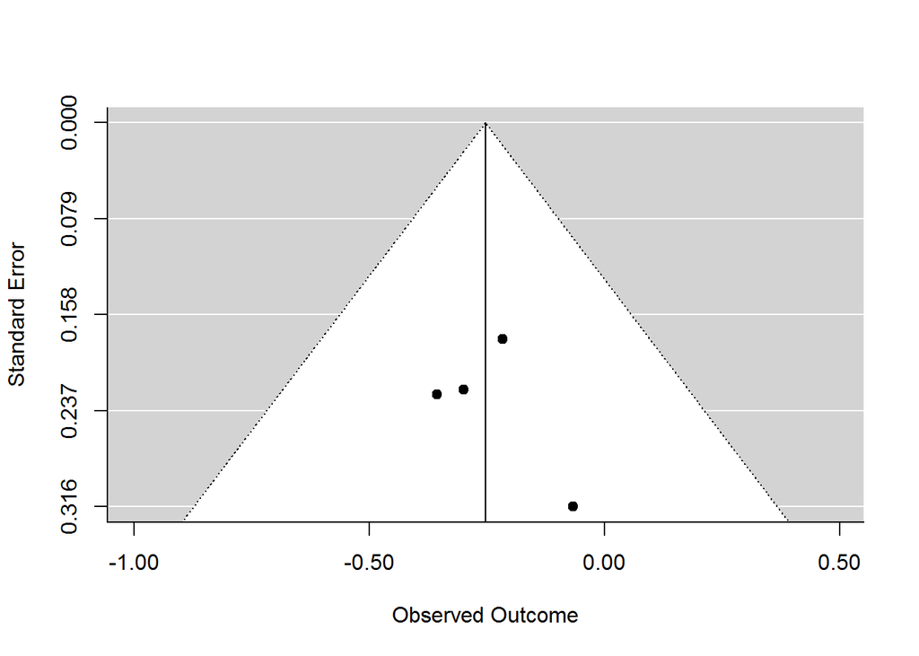

```
##
## Estimated number of missing studies on the left side: 0 (SE = 1.5649)
##
## Random-Effects Model (k = 4; tau^2 estimator: REML)
##
## tau^2 (estimated amount of total heterogeneity): 0 (SE = 0.0398)
## tau (square root of estimated tau^2 value):      0
## I^2 (total heterogeneity / total variability):   0.00%
## H^2 (total variability / sampling variability):  1.00
##
## Test for Heterogeneity:
## Q(df = 3) = 0.6443, p-val = 0.8862
##
## Model Results:
##
## estimate       se     zval     pval    ci.lb    ci.ub
##  -0.2526   0.1104  -2.2874   0.0222  -0.4691  -0.0362        *
##
## ---
## Signif. codes:  0 '***' 0.001 '**' 0.01 '*' 0.05 '.' 0.1 ' ' 1
```

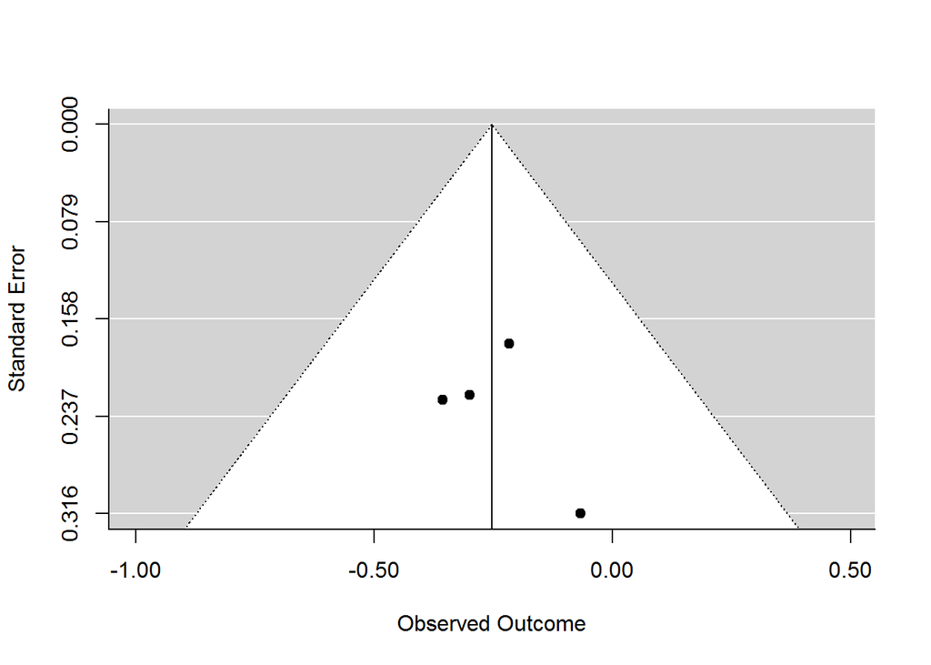

```
##
## Fail-safe N Calculation Using the Rosenthal Approach
##
## Observed Significance Level: 0.0145
## Target Significance Level:   0.05
##
## Fail-safe N: 4
```

Note that all the points lie in the funnel and are fairly symmetric looking, the trimfill method suggests the number of estimated missing studies is $0$ and the fil-safe $N$ is $4$ which is pretty small. The publication bias for the other methods is also identical.

We test for the Publication Bias using the Begg and Egger’s test, which are the Regression and Rank tests for funnel plot asymmetry.

```
##
## Regression Test for Funnel Plot Asymmetry
##
## model:     mixed-effects meta-regression model
## predictor: standard error
##
## test for funnel plot asymmetry: z = 0.3210, p = 0.7482
```

```
##
## Rank Correlation Test for Funnel Plot Asymmetry
##
## Kendall's tau = 0.0000, p = 1.0000
```

## Relative Risk (RR) analysis

The relative risk and its variance are given by

```
##                Y          V
## [1,] -0.17273443 0.01784688
## [2,] -0.23823407 0.02294994
## [3,] -0.03390155 0.02614943
## [4,] -0.12206116 0.01022272
```

```
##
## Fixed-Effects Model (k = 4)
##
##   logLik  deviance       AIC       BIC      AICc
##   3.8669    0.9421   -5.7338   -6.3475   -3.7338
##
## Test for Heterogeneity:
## Q(df = 3) = 0.9421, p-val = 0.8153
##
## Model Results:
##
## estimate       se     zval     pval    ci.lb    ci.ub
##  -0.1413   0.0651  -2.1689   0.0301  -0.2690  -0.0136        *
##
## ---
## Signif. codes:  0 '***' 0.001 '**' 0.01 '*' 0.05 '.' 0.1 ' ' 1
```

```
## The confidence interval for the Relative  Risk is given by : CI.lb= 0.7641773 Est= 0.8682436 CI.ub= 0.9864818
```

```
##       weights
## [1,] 23.77587
## [2,] 18.48916
## [3,] 16.22693
## [4,] 41.50804
```

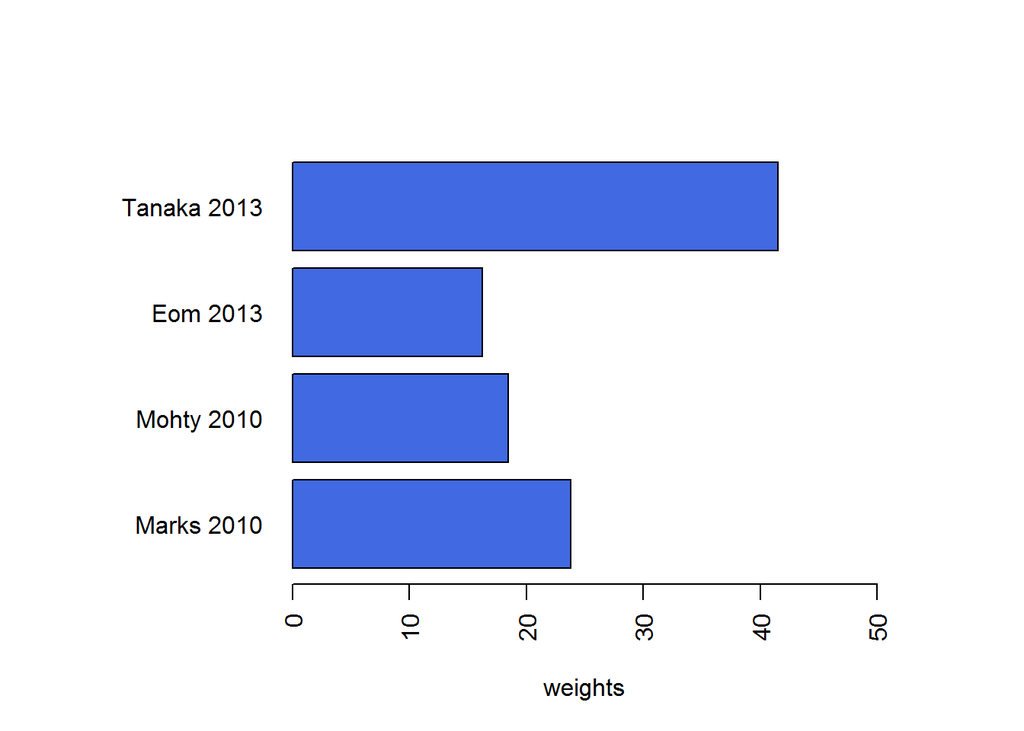

```
##
## Random-Effects Model (k = 4; tau^2 estimator: DL)
##
##   logLik  deviance       AIC       BIC      AICc
##   3.8669    0.9421   -3.7338   -4.9612    8.2662
##
## tau^2 (estimated amount of total heterogeneity): 0 (SE = 0.0146)
## tau (square root of estimated tau^2 value):      0
## I^2 (total heterogeneity / total variability):   0.00%
## H^2 (total variability / sampling variability):  1.00
##
## Test for Heterogeneity:
## Q(df = 3) = 0.9421, p-val = 0.8153
##
## Model Results:
##
## estimate       se     zval     pval    ci.lb    ci.ub
##  -0.1413   0.0651  -2.1689   0.0301  -0.2690  -0.0136        *
##
## ---
## Signif. codes:  0 '***' 0.001 '**' 0.01 '*' 0.05 '.' 0.1 ' ' 1
```

```
##       weights
## [1,] 23.77587
## [2,] 18.48916
## [3,] 16.22693
## [4,] 41.50804
```

```
##
## Random-Effects Model (k = 4; tau^2 estimator: REML)
##
##   logLik  deviance       AIC       BIC      AICc
##   2.7478   -5.4956   -1.4956   -3.2984   10.5044
##
## tau^2 (estimated amount of total heterogeneity): 0 (SE = 0.0141)
## tau (square root of estimated tau^2 value):      0
## I^2 (total heterogeneity / total variability):   0.00%
## H^2 (total variability / sampling variability):  1.00
##
## Test for Heterogeneity:
## Q(df = 3) = 0.9421, p-val = 0.8153
##
## Model Results:
##
## estimate       se     zval     pval    ci.lb    ci.ub
##  -0.1413   0.0651  -2.1689   0.0301  -0.2690  -0.0136        *
##
## ---
## Signif. codes:  0 '***' 0.001 '**' 0.01 '*' 0.05 '.' 0.1 ' ' 1
```

```
##       weights
## [1,] 23.77587
## [2,] 18.48916
## [3,] 16.22693
## [4,] 41.50804
```

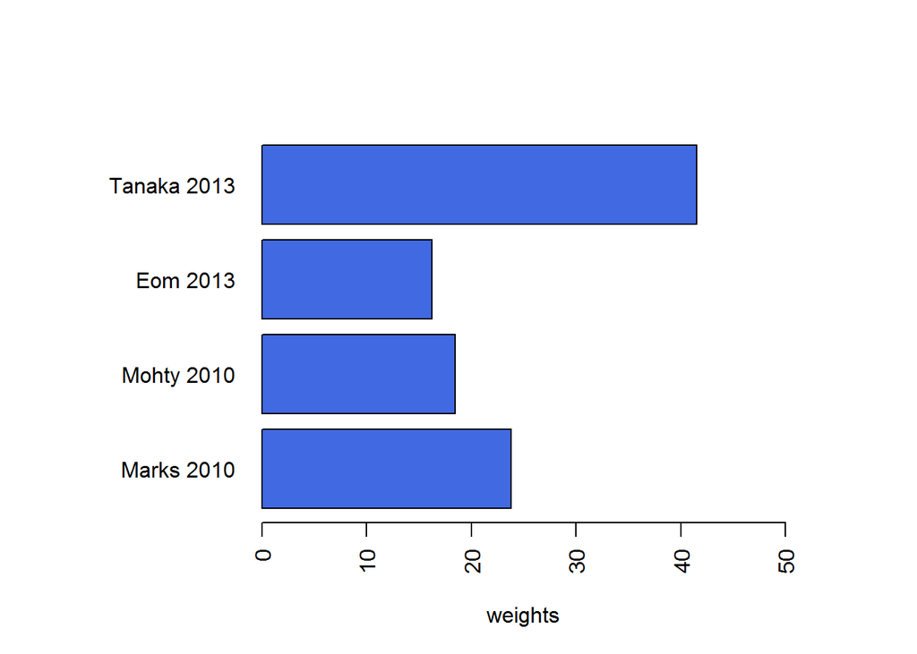

The heterogeneity measures for Fixed effect method

```
##
##        estimate  ci.lb   ci.ub
## tau^2        NA 0.0000  0.0792
## tau          NA 0.0000  0.2814
## I^2(%)       NA 0.0000 81.5514
## H^2          NA 1.0000  5.4205
```

The heterogeneity measure for the Random effect DL method

```
##
##        estimate  ci.lb   ci.ub
## tau^2    0.0000 0.0000  0.0792
## tau      0.0000 0.0000  0.2814
## I^2(%)   0.0000 0.0000 81.5514
## H^2      1.0000 1.0000  5.4205
```

The heterogeneity measures for the Random effect REML method

```
##
##        estimate  ci.lb   ci.ub
## tau^2    0.0000 0.0000  0.0792
## tau      0.0000 0.0000  0.2814
## I^2(%)   0.0000 0.0000 81.5514
## H^2      1.0000 1.0000  5.4205
```

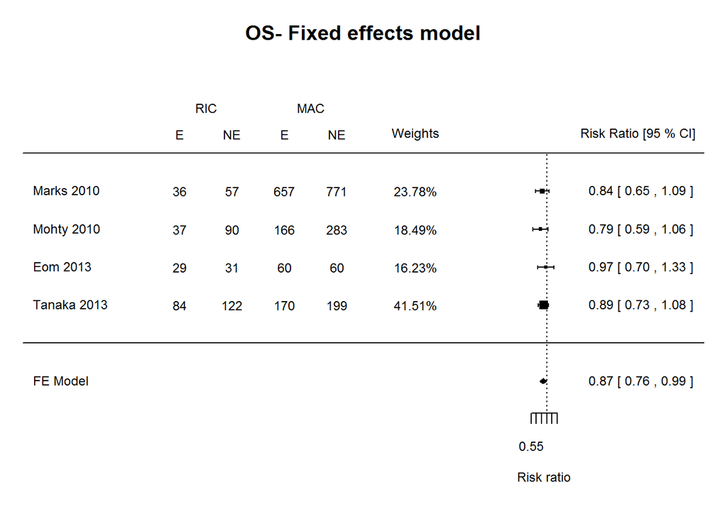

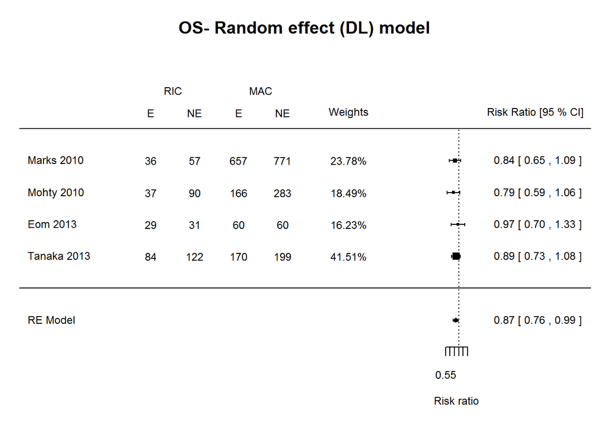

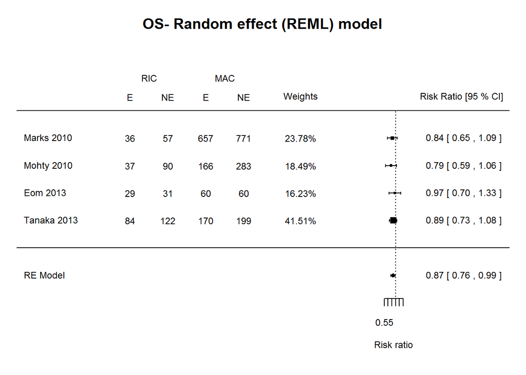

We now consider how sensitive the method is to the removal of one of the trials. For this, we only apply the leave one out sensitivity analysis on the REML random effects method.

```
##   estimate     se    zval   pval   ci.lb   ci.ub      Q     Qp   tau2
## 1  -0.1315 0.0746 -1.7621 0.0781 -0.2777  0.0148 0.8694 0.6475 0.0000
## 2  -0.1193 0.0722 -1.6534 0.0983 -0.2607  0.0221 0.4396 0.8027 0.0000
## 3  -0.1621 0.0712 -2.2774 0.0228 -0.3016 -0.0226 0.4157 0.8123 0.0000
## 4  -0.1549 0.0852 -1.8189 0.0689 -0.3219  0.0120 0.8803 0.6439 0.0000
##       I2     H2
## 1 0.0000 1.0000
## 2 0.0000 1.0000
## 3 0.0000 1.0000
## 4 0.0000 1.0000
```

Note that the $Qp$ does not change drastically if we leave one of the trials out. This means that our process is not very sensitive to any given trial.

We now look at the Funnel plot in order to determine the Publicattion Bias

First we consider the Publication Bias for the REML Random Effects model. That for the other models is also same

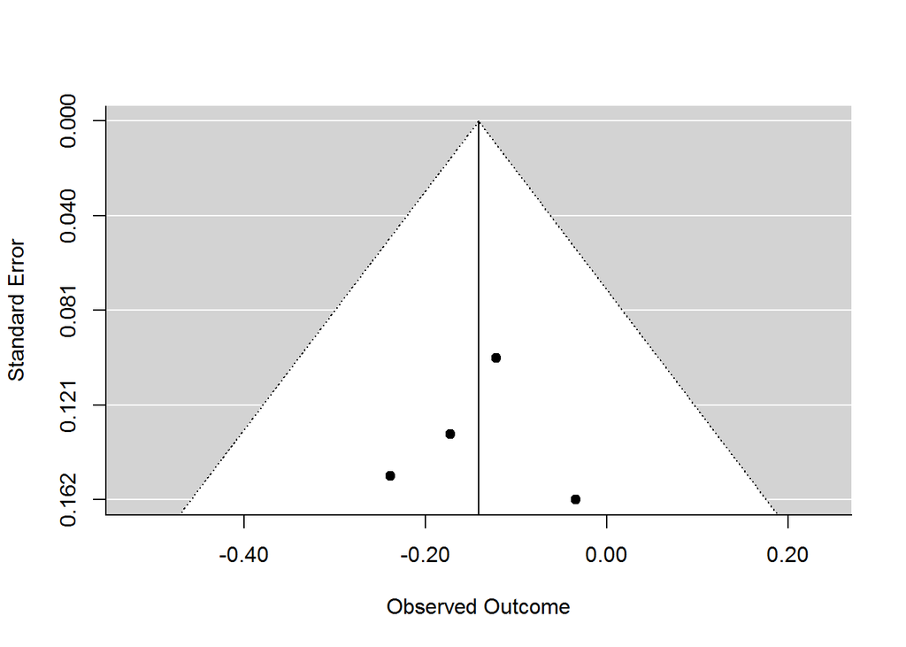

```
##
## Estimated number of missing studies on the right side: 0 (SE = 1.5649)
##
## Random-Effects Model (k = 4; tau^2 estimator: REML)
##
## tau^2 (estimated amount of total heterogeneity): 0 (SE = 0.0141)
## tau (square root of estimated tau^2 value):      0
## I^2 (total heterogeneity / total variability):   0.00%
## H^2 (total variability / sampling variability):  1.00
##
## Test for Heterogeneity:
## Q(df = 3) = 0.9421, p-val = 0.8153
##
## Model Results:
##
## estimate       se     zval     pval    ci.lb    ci.ub
##  -0.1413   0.0651  -2.1689   0.0301  -0.2690  -0.0136        *
##
## ---
## Signif. codes:  0 '***' 0.001 '**' 0.01 '*' 0.05 '.' 0.1 ' ' 1
```

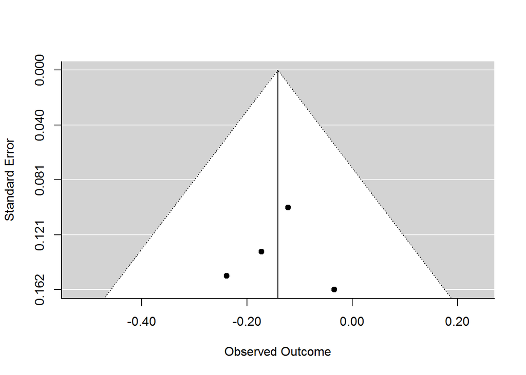

```
##
## Fail-safe N Calculation Using the Rosenthal Approach
##
## Observed Significance Level: 0.0161
## Target Significance Level:   0.05
##
## Fail-safe N: 3
```

We test for the Publication Bias using the Begg and Egger’s test

```
##
## Regression Test for Funnel Plot Asymmetry
##
## model:     mixed-effects meta-regression model
## predictor: standard error
##
## test for funnel plot asymmetry: z = -0.0568, p = 0.9547
```

```
##
## Rank Correlation Test for Funnel Plot Asymmetry
##
## Kendall's tau = 0.0000, p = 1.0000
```